# Chapter 10: Unsupervised Learning

Paulo Loyola

```r
library(ISLR)
```

## **Conceptual**

**3)**

```r
x1 = c(1, 1, 0, 5, 6, 4)
x2 = c(4, 3, 4, 1, 2, 0)
```

**a)**

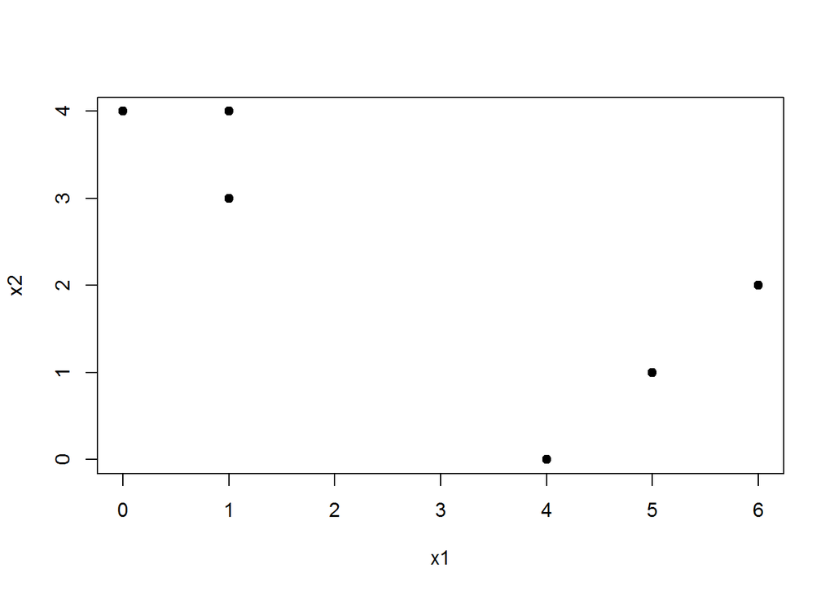

```r
data = data.frame(x1, x2)
plot(x2 ~ x1, data, pch = 19)
```

**b)**

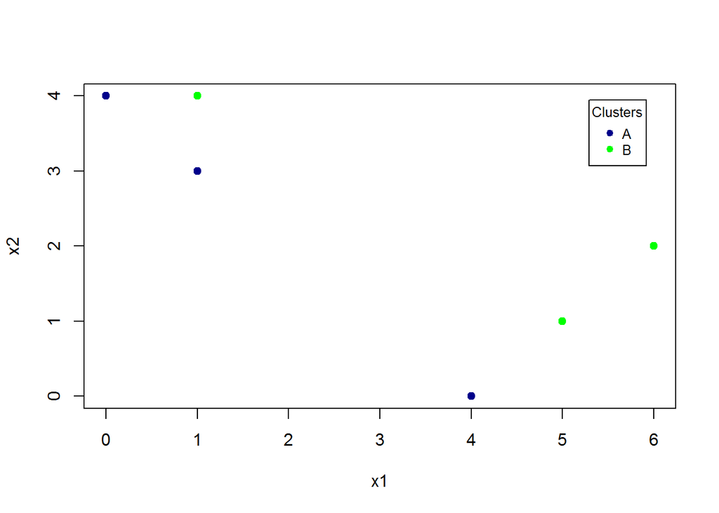

```r
set.seed(1)
group = sample(6, 3)
A = data[group,]
B = data[-group,]
data$cluster = ifelse(row.names(data) %in% row.names(A), 1, 0)
plot(x2 ~ x1, data, pch = 19, col = ifelse(cluster == 1, "darkblue", "green"))
legend("topright", inset=.05, title="Clusters", c("A","B"), pch = 19, col = c("darkblue", "green"), cex = 0.8)
```

**c)**

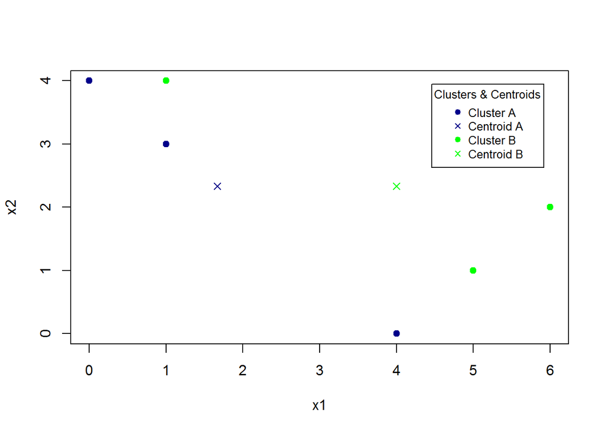

```r
centroid.A = c(mean(data[group, c("x1")]), mean(data[group, c("x2")]))
centroid.B = c(mean(data[-group, c("x1")]), mean(data[-group, c("x2")]))
plot(x2 ~ x1, data, pch = 19, col = ifelse(cluster == 1, "darkblue", "green"))
points(centroid.A[2] ~ centroid.A[1], pch = 4, col="darkblue")
points(centroid.B[2] ~ centroid.B[1], pch = 4, col="green")
legend("topright", inset=.05, title = "Clusters & Centroids", c("Cluster A", "Centroid A","Cluster B", "Centroid B"), pch = c(19, 4, 19, 4), col = c("darkblue", "darkblue", "green", "green"), cex = 0.8)
```

**d)**

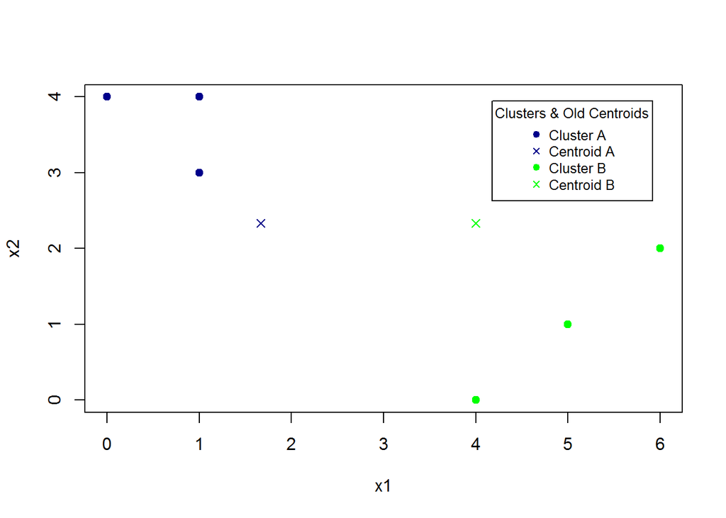

```r
data$distA = (x1 - centroid.A[1])^2 + (x2 - centroid.A[2])^2
data$distB = (x1 - centroid.B[1])^2 + (x2 - centroid.B[2])^2
data$cluster = ifelse(data$distA < data$distB, 1, 0)
plot(x2 ~ x1, data, pch = 19, col = ifelse(cluster == 1, "darkblue", "green"))
points(centroid.A[2] ~ centroid.A[1], pch = 4, col="darkblue")
points(centroid.B[2] ~ centroid.B[1], pch = 4, col="green")
legend("topright", inset=.05, title = "Clusters & Old Centroids", c("Cluster A", "Centroid A","Cluster B", "Centroid B"), pch = c(19, 4, 19, 4), col = c("darkblue", "darkblue", "green", "green"), cex = 0.8)
```

**e) and f)**

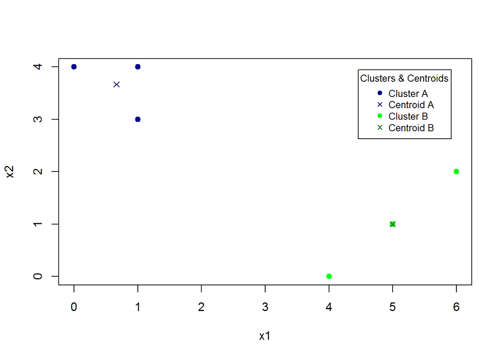

```r
centroid.A = c(mean(subset(data, cluster == 1)[,c("x1")]), mean(subset(data, cluster == 1)[,c("x2")]))
centroid.B = c(mean(subset(data, cluster == 0)[,c("x1")]), mean(subset(data, cluster == 0)[,c("x2")]))
plot(x2 ~ x1, data, pch = 19, col = ifelse(cluster == 1, "darkblue", "green"))
points(centroid.A[2] ~ centroid.A[1], pch = 4, col="darkblue")
points(centroid.B[2] ~ centroid.B[1], pch = 4, col="darkgreen")
legend("topright", inset=.05, title = "Clusters & Centroids", c("Cluster A", "Centroid A","Cluster B", "Centroid B"), pch = c(19, 4, 19, 4), col = c("darkblue", "darkblue", "green", "darkgreen"), cex = 0.8)
```

**4)**

**a)** The fusion will occur higher at the complete linkage, since this method takes in account the maximum distance between clusters. If the maximum distance is the same as the minimum distance, them the fusion will occur at the same point using the single linkage or the complete linkage.

**b)** They will fuse at the same point. Since we are dealing with single observations, the distance between them will be the same not mattering the method we are using.

**5)**

In the left panel we would end up with a cluster containing shoppers 1, 2 and 8 and another cluster with all of the other shoppers. This would happen because the shoppers who bought at least 8 pairs of socks would form a cluster with centroid (9; 0.333) and the others would form a cluster with centroid (6.2; 0.6).

In the center and in the right panels the clusters would end up containing in one the shoppers that bought computers and in the other the shoppers who didn’t. The distance between the computers is greater than the one between socks.

**6)**

**a)** The first component explaining 10% of the variation means that this variable that is a linear combination of all the 100 tissues in the dataset forms a vector that accounts for 10% of the variation in the dataset. You can understand 10% of the behaviour of the genes by just using this first component.

**7)**

```r
set.seed(1)
data = t(scale(t(USArrests)))
distance = as.matrix(dist(data)^2)
distance = distance[lower.tri(distance)]

correlation <- cor(t(data))
correlation <- 1 - correlation
correlation <- correlation[lower.tri(correlation)]

cor(distance, correlation)
```

```
## [1] 1
```

```r
summary(distance/correlation)
```

```
##    Min. 1st Qu.  Median    Mean 3rd Qu.    Max.
##       6       6       6       6       6       6
```

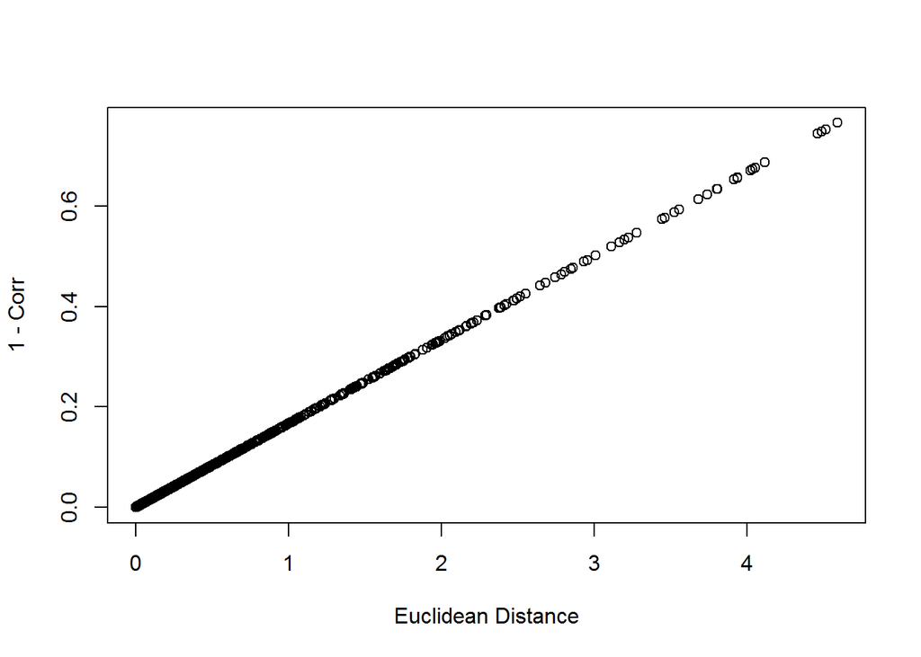

```r
plot(distance, correlation, xlab = "Euclidean Distance", ylab = "1 - Corr")
```

**8)**

**a)**

```r
pr.out = prcomp(USArrests, scale = TRUE, center = TRUE)
variance = pr.out$sdev^2
pve = variance / (sum(variance))
pve
```

```
## [1] 0.62006039 0.24744129 0.08914080 0.04335752
```

**b)**

```r
loadings = pr.out$rotation
pve2 = rep(NA, 4)
dmean = apply(USArrests, 2, mean)
dsdev = sqrt(apply(USArrests, 2, var))
dsc = sweep(USArrests, MARGIN=2, dmean, "-")
dsc = sweep(dsc, MARGIN=2, dsdev, "/")
for (i in 1:4) {
  proto_x = sweep(dsc, MARGIN=2, loadings[,i], "*")
  pc_x = apply(proto_x, 1, sum)
  pve2[i] = sum(pc_x^2)
}
pve2 = pve2/sum(dsc^2)
pve2
```

```
## [1] 0.62006039 0.24744129 0.08914080 0.04335752
```

**9)**

**a)**

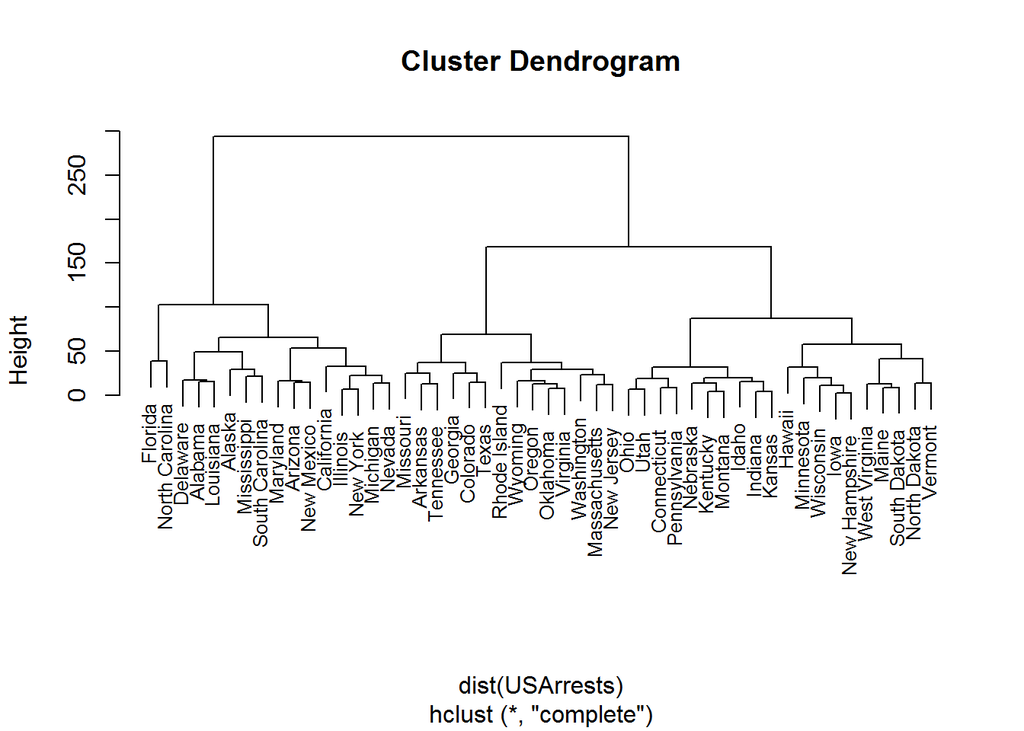

```r
hcluster = hclust(dist(USArrests), method = "complete")
plot(hcluster, cex = 0.8)
```

**b)**

```r
cutree(hcluster, 3)
```

```
##        Alabama         Alaska        Arizona       Arkansas     California
##              1              1              1              2              1
##       Colorado    Connecticut       Delaware        Florida        Georgia
##              2              3              1              1              2
##         Hawaii          Idaho       Illinois        Indiana           Iowa
##              3              3              1              3              3
##         Kansas       Kentucky      Louisiana          Maine       Maryland
##              3              3              1              3              1
##  Massachusetts       Michigan      Minnesota    Mississippi       Missouri
##              2              1              3              1              2
##        Montana       Nebraska         Nevada  New Hampshire     New Jersey
##              3              3              1              3              2
##     New Mexico       New York North Carolina   North Dakota           Ohio
##              1              1              1              3              3
##       Oklahoma         Oregon   Pennsylvania   Rhode Island South Carolina
##              2              2              3              2              1
##   South Dakota      Tennessee          Texas           Utah        Vermont
##              3              2              2              3              3
##       Virginia     Washington  West Virginia      Wisconsin        Wyoming
##              2              2              3              3              2
```

```r
table(cutree(hcluster, 3))
```

```
##
##  1  2  3
## 16 14 20
```

**c)**

```r
scalled = data.frame(scale(USArrests))
hcluster2 = hclust(dist(scalled), method = "complete")
```

**d)**

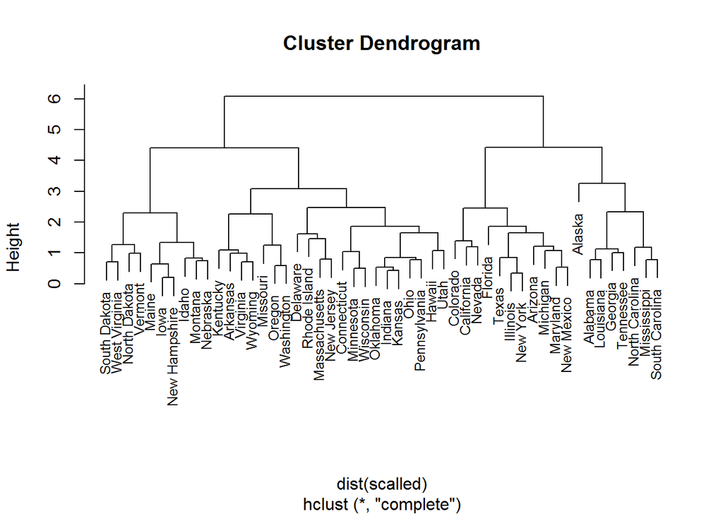

```r
plot(hcluster2, cex = 0.8)
```

```r
cutree(hcluster2, 3)
```

```
##        Alabama         Alaska        Arizona       Arkansas     California
##              1              1              2              3              2
##       Colorado    Connecticut       Delaware        Florida        Georgia
##              2              3              3              2              1
##         Hawaii          Idaho       Illinois        Indiana           Iowa
##              3              3              2              3              3
##         Kansas       Kentucky      Louisiana          Maine       Maryland
##              3              3              1              3              2
##  Massachusetts       Michigan      Minnesota    Mississippi       Missouri
##              3              2              3              1              3
##        Montana       Nebraska         Nevada  New Hampshire     New Jersey
##              3              3              2              3              3
##     New Mexico       New York North Carolina   North Dakota           Ohio
##              2              2              1              3              3
##       Oklahoma         Oregon   Pennsylvania   Rhode Island South Carolina
##              3              3              3              3              1
##   South Dakota      Tennessee          Texas           Utah        Vermont
##              3              1              2              3              3
##       Virginia     Washington  West Virginia      Wisconsin        Wyoming
##              3              3              3              3              3
```

```r
table(cutree(hcluster2, 3))
```

```
##
##  1  2  3
##  8 11 31
```

```r
table(non.normalized = cutree(hcluster, 3), normalized = cutree(hcluster2, 3))
```

```
##               normalized
## non.normalized  1  2  3
##              1  6  9  1
##              2  2  2 10
##              3  0  0 20
```

We can see that scaling the variables affects to which clusters the states are assigned. In this case, seems reasonable to scale the data in order to make a better comparison between the different types of crimes and to don’t let the variable UrbanPop distort the analysis.

**10)**

**a)**

```r
data = data.frame(rep(c(1,2,3), 20))
names(data) = "class"
set.seed(1)
for (i in 1:50) {
  if (i %% 3 == 0){
    data[,paste("x", i, sep="")] = rnorm(60, 0, i)
  } else if (i %% 2 == 0) {
    data[,paste("x", i, sep="")] = runif(60, -i, i)
  } else {
    data[,paste("x", i, sep="")] = rpois(60, i)
  }
}
class1 = cbind(rep(1, 20), subset(data, class == 1)[,2:51] - 20)
names(class1)[1] = "class"
class3 = cbind(rep(3, 20), subset(data, class == 3)[,2:51] + 50)
names(class3)[1] = "class"
data = rbind(class1, class3, subset(data, class == 2))
data$class = as.factor(data$class)
```

**b)**

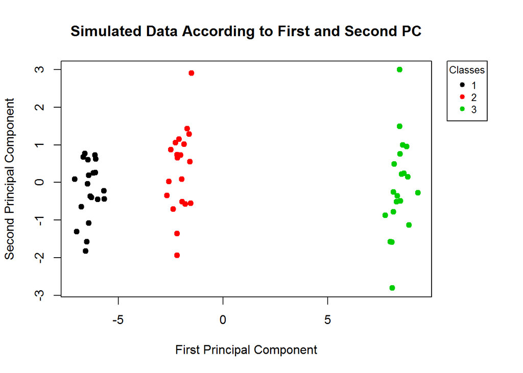

```r
pr.out = prcomp(data[,2:51], scale = TRUE)

par(mar=c(5.1, 4.1, 4.1, 6.1), xpd=TRUE)
plot(pr.out$x[,2] ~ pr.out$x[,1], col = data$class, pch = 19, main = "Simulated Data According to First and Second PC", xlab = "First Principal Component", ylab = "Second Principal Component")
legend("topright", inset = c(-0.15, 0), title = "Classes", c("1", "2", "3"), pch = 19, col = c(1, 2, 3), cex = 0.8)
```

**c)**

```r
km.3 = kmeans(data[,2:51], 3, nstart = 50)
table(kmeans = km.3$cluster, real.class = data$class)
```

```
##       real.class
## kmeans  1  2  3
##      1 20  0  0
##      2  0 20  0
##      3  0  0 20
```

The results are perfect. K-means correctly identified the three classes.

**d)**

```r
km.2 = kmeans(data[,2:51], 2, nstart = 50)
table(kmeans = km.2$cluster, real.class = data$class)
```

```
##       real.class
## kmeans  1  2  3
##      1 20 20  0
##      2  0  0 20
```

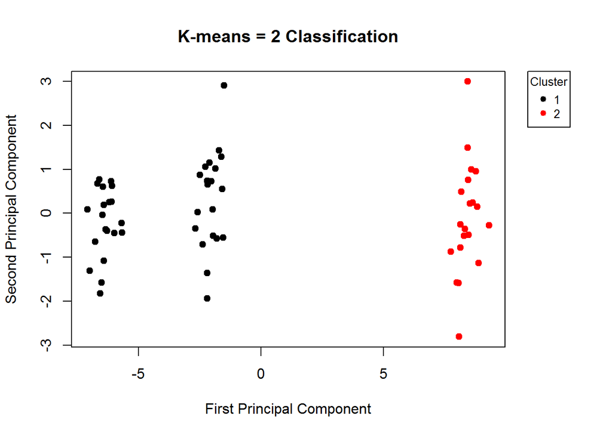

```r
par(mar=c(5.1, 4.1, 4.1, 6.1), xpd=TRUE)
plot(pr.out$x[,2] ~ pr.out$x[,1], col = km.2$cluster, pch = 19, main = "K-means = 2 Classification", xlab = "First Principal Component", ylab = "Second Principal Component")
legend("topright", inset = c(-0.15, 0), title = "Cluster", c("1", "2"), pch = 19, col = c(1, 2), cex = 0.8)
```

Now, all the observations that belong to class 2 are added to the first cluster. The second cluster, now, identifies class three.

**e)**

```r
km.4 = kmeans(data[,2:51], 4, nstart = 50)
table(kmeans = km.4$cluster, real.class = data$class)
```

```
##       real.class
## kmeans  1  2  3
##      1  0  0  6
##      2 20  0  0
##      3  0 20  0
##      4  0  0 14
```

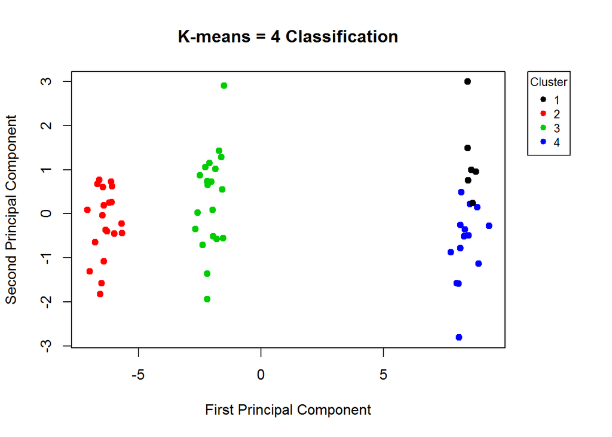

```r
par(mar=c(5.1, 4.1, 4.1, 6.1), xpd=TRUE)
plot(pr.out$x[,2] ~ pr.out$x[,1], col = km.4$cluster, pch = 19, main = "K-means = 4 Classification", xlab = "First Principal Component", ylab = "Second Principal Component")
legend("topright", inset = c(-0.15, 0), title = "Cluster", c("1", "2", "3", "4"), pch = 19, col = c(1, 2, 3, 4), cex = 0.8)
```

Adding a forth cluster divided the third cluster in two parts separating its observations that ranked higher in the second dimension of the Principal Component from the ones that ranked lower.

**f)**

```r
km.pc = kmeans(data.frame(pr.out$x[,1], pr.out$x[,2]), 3, nstart = 50)
table(kmeans = km.pc$cluster, real.class = data$class)
```

```
##       real.class
## kmeans  1  2  3
##      1  0  0 20
##      2 20  0  0
##      3  0 20  0
```

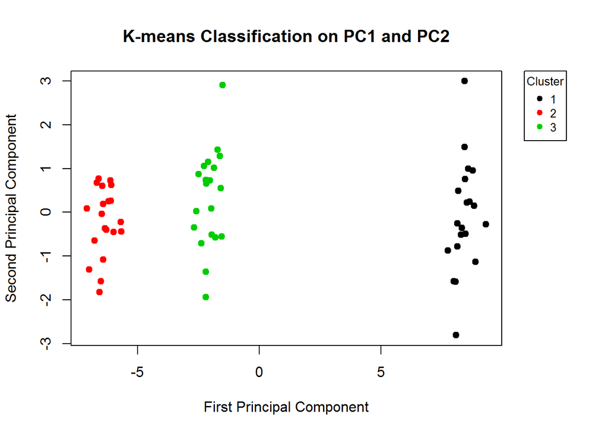

```r
par(mar=c(5.1, 4.1, 4.1, 6.1), xpd=TRUE)
plot(pr.out$x[,2] ~ pr.out$x[,1], col = km.pc$cluster, pch = 19, main = "K-means Classification on PC1 and PC2", xlab = "First Principal Component", ylab = "Second Principal Component")
legend("topright", inset = c(-0.15, 0), title = "Cluster", c("1", "2", "3"), pch = 19, col = c(1, 2, 3), cex = 0.8)
```

Again, the three classes are separated correctly. The clusters don’t identify the classes that they did in c), but they separated the data correctly into the three classes.

**g)**

```r
scaled = data.frame(cbind(data[,1], scale(data[,2:51])))

km.scaled = kmeans(scaled, 3, nstart = 50)
table(kmeans = km.scaled$cluster, real.class = data$class)
```

```
##       real.class
## kmeans  1  2  3
##      1  0 20  0
##      2  0  0 20
##      3 20  0  0
```

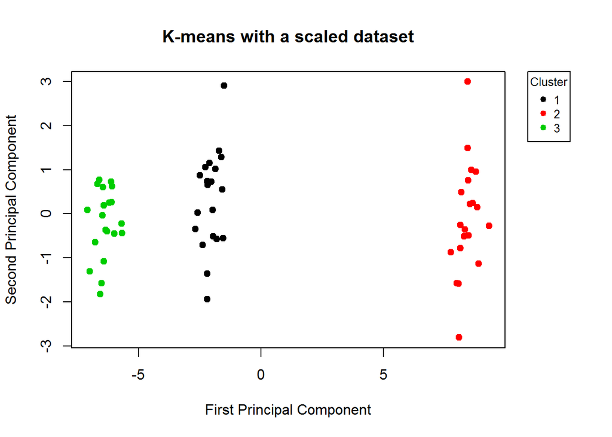

```r
par(mar=c(5.1, 4.1, 4.1, 6.1), xpd=TRUE)
plot(pr.out$x[,2] ~ pr.out$x[,1], col = km.scaled$cluster, pch = 19, main = "K-means with a scaled dataset", xlab = "First Principal Component", ylab = "Second Principal Component")
legend("topright", inset = c(-0.15, 0), title = "Cluster", c("1", "2", "3"), pch = 19, col = c(1, 2, 3), cex = 0.8)
```

The same as the previous item.

**11)**

**a)**

```r
data = read.csv(url("http://www-bcf.usc.edu/~gareth/ISL/Ch10Ex11.csv"), header = F)
```

**b)**

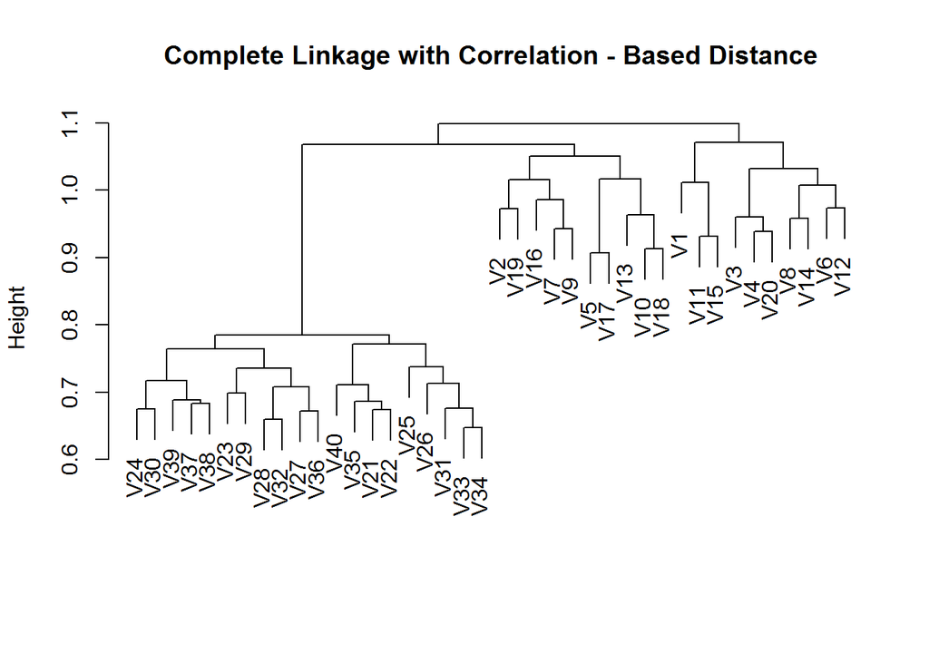

```r
hcor.complete = hclust(as.dist(1 - cor(data)), method = "complete")
plot(hcor.complete, main = "Complete Linkage with Correlation - Based Distance", xlab = "", sub = "")
```

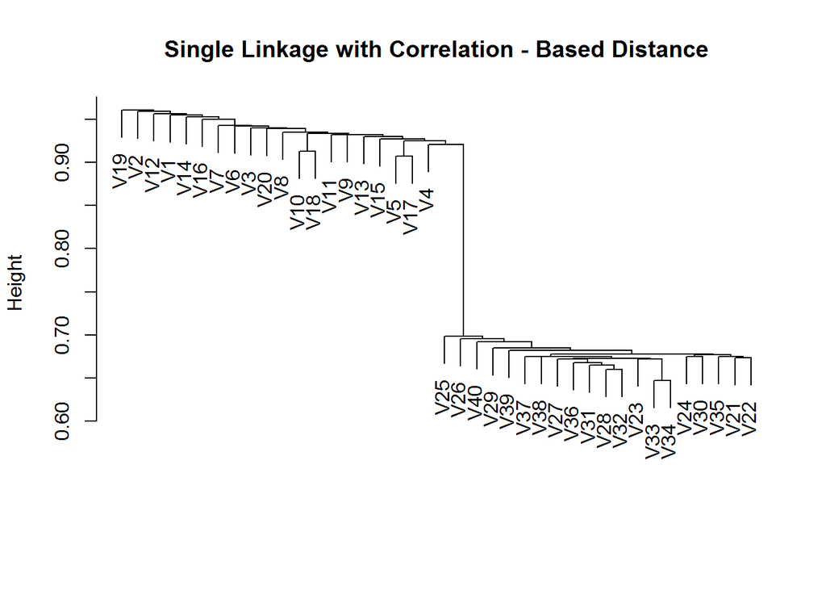

```r
hcor.single = hclust(as.dist(1 - cor(data)), method = "single")
plot(hcor.single, main = "Single Linkage with Correlation - Based Distance", xlab = "", sub = "")
```

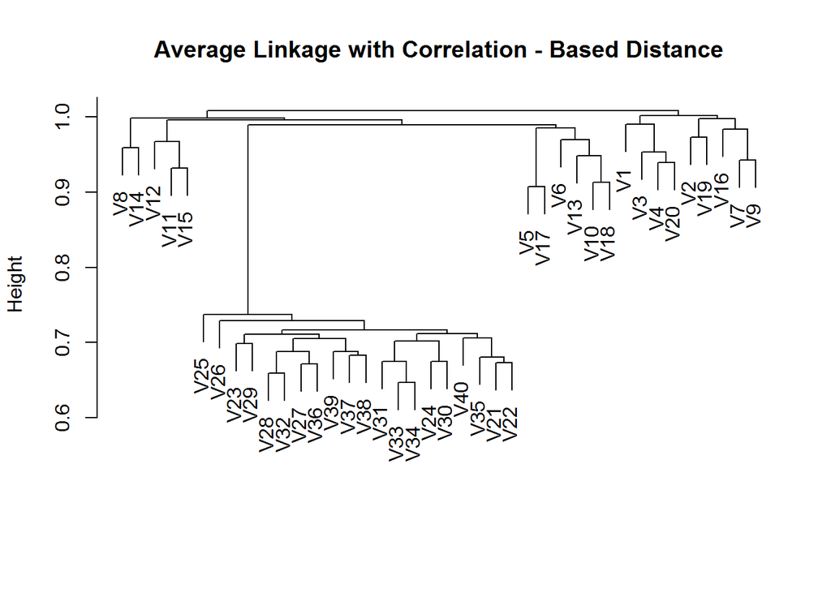

```r
hcor.average = hclust(as.dist(1 - cor(data)), method = "average")
plot(hcor.average, main = "Average Linkage with Correlation - Based Distance", xlab = "", sub = "")
```

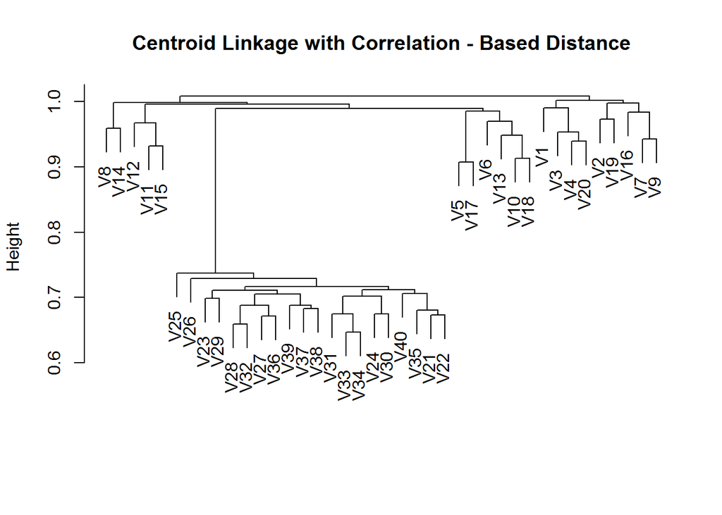

```r
hcor.centroid = hclust(as.dist(1 - cor(data)), method = "centroid")
plot(hcor.average, main = "Centroid Linkage with Correlation - Based Distance", xlab = "", sub = "")
```

The groups variate a lot according to the type of linkage used.